# NYPD Shootings 2006-2020

6/13/2021

## Introduction

In my research, I explored gun violence in New York City. They have had a large increase in shootings. 2020 was very hard on the economy due to the pandemic. This led to a large disruption in daily lives and increased unemployment rates among many other things.

*Install packages: tidyverse, ggplot2, viridis, lubridate, hrbrthemes, readxl, ggpubr, data.table, leaflet, sp, rgdal, KernSmooth, raster, httr.*

The NYPD data was collected from *https://catalog.data.gov/dataset/nypd-shooting-incident-data-historic*. Unemployment data was collected from *https://www.bls.gov/lau/tables.htm*.

For the NYPD dataset, it is best to drop NA’s. Extrapolating or filling in with common data would create a bias.

## Summary:

```r
# SELECT ONLY COLUMNS NEEDED
nypd_shooting = subset(nypd_shooting, select = -c(INCIDENT_KEY,
    STATISTICAL_MURDER_FLAG,JURISDICTION_CODE, LOCATION_DESC, X_COORD_CD,
    Y_COORD_CD, Lon_Lat))
# CONVERT DATA TYPES
nypd_shooting$OCCUR_DATE <- as.Date(nypd_shooting$OCCUR_DATE, "%m/%d/%Y")
nypd_shooting$PRECINCT <- as.factor(nypd_shooting$PRECINCT)
nypd_shooting$BORO <- as.factor(nypd_shooting$BORO)
nypd_shooting$PERP_AGE_GROUP <- as.factor(nypd_shooting$PERP_AGE_GROUP)
nypd_shooting$PERP_SEX <- as.factor(nypd_shooting$PERP_SEX)
nypd_shooting$PERP_RACE <- as.factor(nypd_shooting$PERP_RACE)
nypd_shooting$VIC_AGE_GROUP <- as.factor(nypd_shooting$VIC_AGE_GROUP)
nypd_shooting$VIC_SEX <- as.factor(nypd_shooting$VIC_SEX)
nypd_shooting$VIC_RACE <- as.factor(nypd_shooting$VIC_RACE)
# CREATE YEAR COLUMN
nypd_shooting$year <- format(nypd_shooting$OCCUR_DATE, format = "%Y")
nypd_shooting$year <- as.factor(nypd_shooting$year)

nypd_shooting_summary <- subset(nypd_shooting, select = c(year, BORO, PERP_AGE_GROUP, PERP_SEX, PERP_RACE, VIC_AGE_GROUP, VIC_SEX, VIC_RACE))
summary(nypd_shooting_summary)
```

```
##       year                  BORO      PERP_AGE_GROUP PERP_SEX
##  2006   : 2055   BRONX        :6700   18-24  :5448   F   :  334
##  2008   : 1958   BROOKLYN     :9722   25-44  :4613   M   :13305
##  2020   : 1942   MANHATTAN    :2921   UNKNOWN:3156   U   : 1504
##  2011   : 1939   QUEENS       :3527   <18    :1354   NA's: 8425
##  2010   : 1910   STATEN ISLAND: 698   45-64  : 481
##  2007   : 1887                        (Other):  57
##  (Other):11877                        NA's   :8459
##           PERP_RACE    VIC_AGE_GROUP   VIC_SEX
##  BLACK         :9855   <18    : 2525   F: 2195
##  WHITE HISPANIC:1961   18-24  : 9000   M:21353
##  UNKNOWN       :1869   25-44  :10287   U:   20
##  BLACK HISPANIC:1081   45-64  : 1536
##  WHITE         : 255   65+    :  155
##  (Other)       : 122   UNKNOWN:   65
##  NA's          :8425
##                            VIC_RACE
##  AMERICAN INDIAN/ALASKAN NATIVE:    9
##  ASIAN / PACIFIC ISLANDER      :  320
##  BLACK                         :16846
##  BLACK HISPANIC                : 2244
##  UNKNOWN                       :  102
##  WHITE                         :  615
##  WHITE HISPANIC                : 3432
```

## Exploring the Data

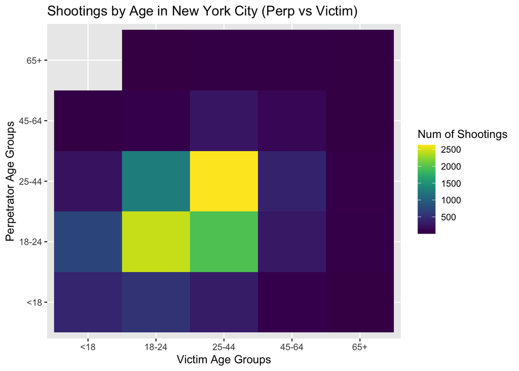

```r
# PLOT 1: COMPARING VICTIM VS PERP BY AGE GROUPS
nypd_by_age <- subset(nypd_shooting, select = c(VIC_AGE_GROUP, PERP_AGE_GROUP))
# FILTERING OUT ANYTHING THAT IS NOT AN AGE GROUP
nypd_by_age <- nypd_by_age[(nypd_by_age$PERP_AGE_GROUP == '65+' | nypd_by_age$PERP_AGE_GROUP == '45-64' | nypd_by_age$PERP_AGE_GROUP == '25-44' | nypd_by_age$PERP_AGE_GROUP == '18-24' | nypd_by_age$PERP_AGE_GROUP == '<18'), ]
nypd_by_age <- nypd_by_age[(nypd_by_age$VIC_AGE_GROUP == '65+' | nypd_by_age$VIC_AGE_GROUP == '45-64' | nypd_by_age$VIC_AGE_GROUP == '25-44' | nypd_by_age$VIC_AGE_GROUP == '18-24' | nypd_by_age$VIC_AGE_GROUP == '<18'), ]
# DROP NA's
nypd_by_age <- drop_na(nypd_by_age, PERP_AGE_GROUP)

# GROUP BY VIC AGE AND PERP AGE
nypd_by_age <- aggregate(nypd_by_age, by=list(nypd_by_age$VIC_AGE_GROUP, nypd_by_age$PERP_AGE_GROUP), FUN=length)
nypd_by_age <- subset(nypd_by_age, select = -c(VIC_AGE_GROUP))
nypd_by_age <- setNames(nypd_by_age, c("VIC_AGE_GROUP", "PERP_AGE_GROUP", "count"))

# PLOT IN HEAT MAP
ggplot(nypd_by_age, aes(x=VIC_AGE_GROUP, y=PERP_AGE_GROUP, fill=count)) +
  geom_tile() +
  scale_fill_viridis(discrete=FALSE, name="Num of Shootings") +
  ggtitle("Shootings by Age in New York City (Perp vs Victim)") +
  xlab("Victim Age Groups") +
  ylab("Perpetrator Age Groups")
```

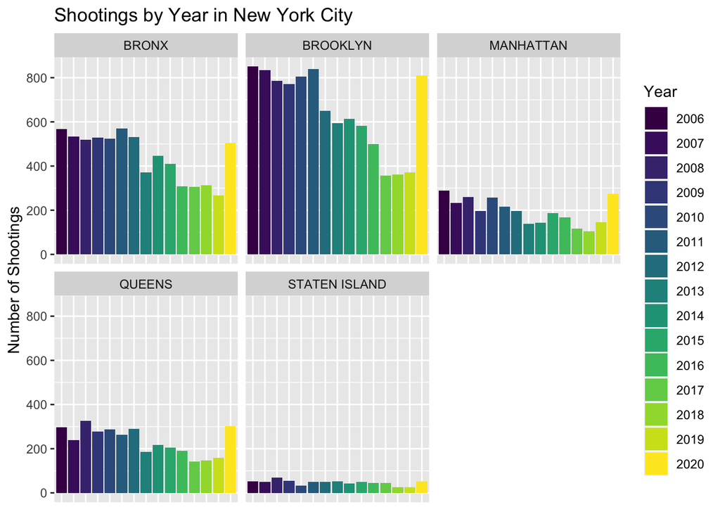

```r
# PLOT 2: COMPARING LOCATION AND YEARS
nypd_by_loc_year <- subset(nypd_shooting, select = c(BORO, year))
# GROUPING BY BORO AND YEAR
nypd_by_loc_year <- aggregate(nypd_by_loc_year, by=list(nypd_by_loc_year$BORO, nypd_by_loc_year$year), FUN=length)
nypd_by_loc_year <- subset(nypd_by_loc_year, select = -c(year))
nypd_by_loc_year <- setNames(nypd_by_loc_year, c("BORO", "year", "count"))

# PLOT IN BAR CHARTS SEPARATELY
ggplot(nypd_by_loc_year, aes(fill=year, y=count, x=year)) +
  geom_bar(position="dodge", stat="identity") +
  scale_fill_viridis(discrete = TRUE, name="Year") +
  ggtitle("Shootings by Year in New York City") +
  facet_wrap(~BORO) +
  theme(axis.title.x=element_blank(),
        axis.text.x=element_blank(),
        axis.ticks.x=element_blank()) +
  ylab("Number of Shootings")
```

Diving in further I decided to gather unemployment data. With the lockdowns, the economy took a big hit. I gathered data from the U.S. Bureau of Labor Statistics. The dataset was listed by county so I converted this data to show Borough’s to compare with shootings. This was done through the “The Official Website of the City of New York” (*https://portal.311.nyc.gov/article/?kanumber=KA-02877*).

This shows Unemployment Rates in New York City from 2006 to 2020. Taking a look at these charts you can see a very similar 2020 spike after a downward trend since 2009 in all Borough’s similar to the shootings. This would highly affect lower income communities which we will explore shortly.

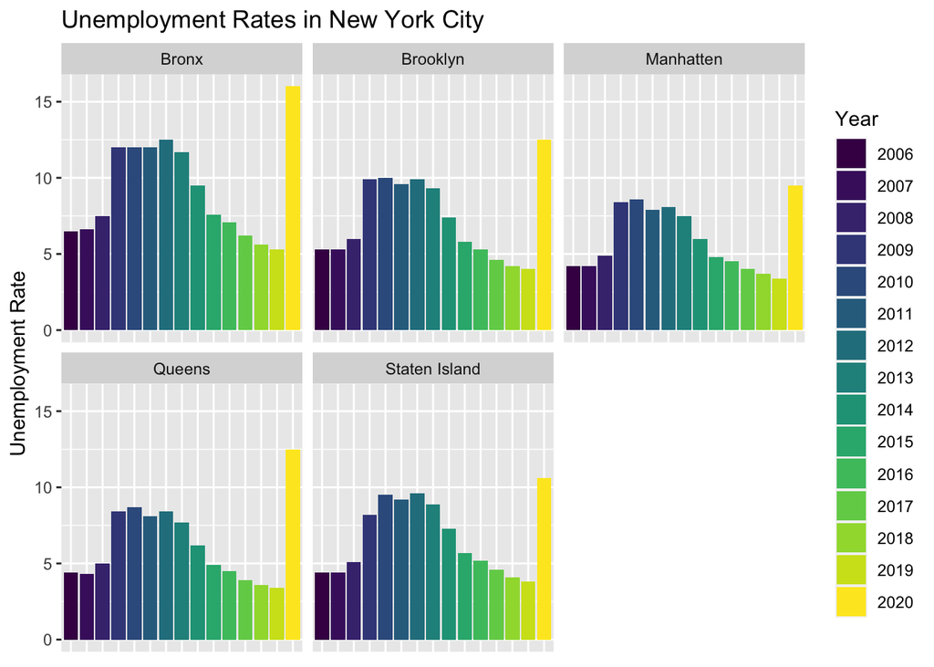

```r
nyc_unemployment <- filter(unemployment, County %in% c('Bronx County, NY', 'Kings County, NY', 'New York County, NY', 'Queens County, NY', 'Richmond County, NY'))
nyc_unemployment['Boro'] <- ifelse(nyc_unemployment$County == "Bronx County, NY", "Bronx",
                                   ifelse(nyc_unemployment$County == "Kings County, NY", "Brooklyn",
                                          ifelse(nyc_unemployment$County == "New York County, NY", "Manhatten",
                                                 ifelse(nyc_unemployment$County == "Queens County, NY", "Queens",
                                                        ifelse(nyc_unemployment$County == "Richmond County, NY", "Staten Island", '')))))


# PLOT 2: COMPARING LOCATION AND YEARS
nyc_unemployment_by_year <- subset(nyc_unemployment, select = c(Boro, Year, Unemployment_Rate))

# PLOT IN BAR CHARTS SEPARATELY
ggplot(nyc_unemployment_by_year, aes(fill=Year, y=Unemployment_Rate, x=Year)) +
  geom_bar(position="dodge", stat="identity") +
  scale_fill_viridis(discrete = TRUE, name="Year") +
  ggtitle("Unemployment Rates in New York City") +
  facet_wrap(~Boro) +
  theme(axis.title.x=element_blank(),
        axis.text.x=element_blank(),
        axis.ticks.x=element_blank()) +
  ylab("Unemployment Rate")
```

### Correlations

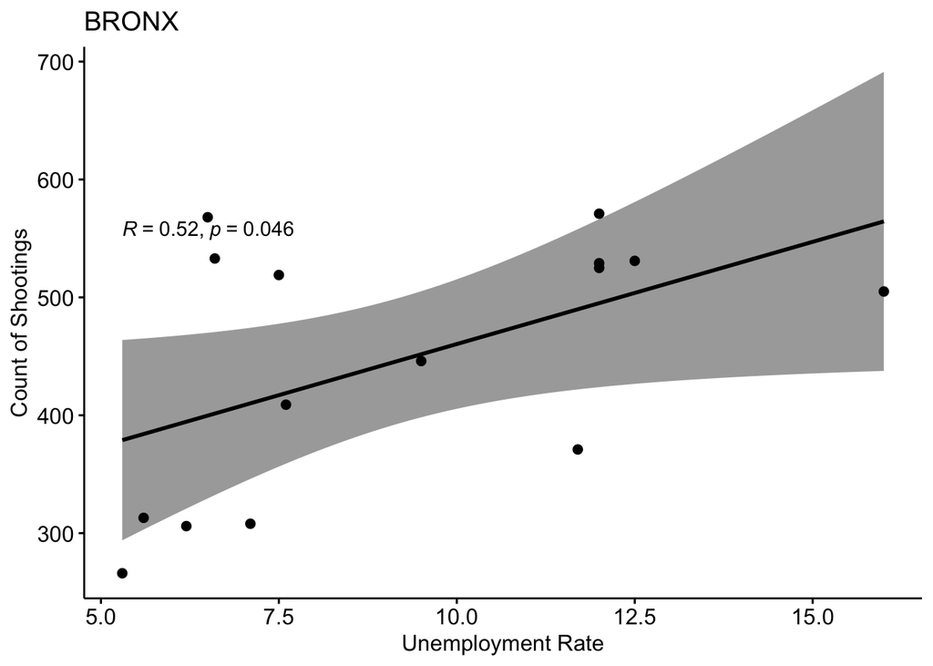

```r
# CORRELATION BETWEEN SHOOTINGS AND UNEMPLOYMENT
# BRONX
bronx_unemployment <- nyc_unemployment_by_year[nyc_unemployment_by_year$Boro == 'Bronx',]
bronx_shootings <- nypd_by_loc_year[nypd_by_loc_year$BORO == 'BRONX',]
bronx <- cbind(bronx_shootings, bronx_unemployment)
ggscatter(bronx, x = "Unemployment_Rate", y = "count",
          add = "reg.line", conf.int = TRUE,
          cor.coef = TRUE, cor.method = "pearson",
          xlab = "Unemployment Rate", ylab = "Count of Shootings") +
          ggtitle("BRONX")
```

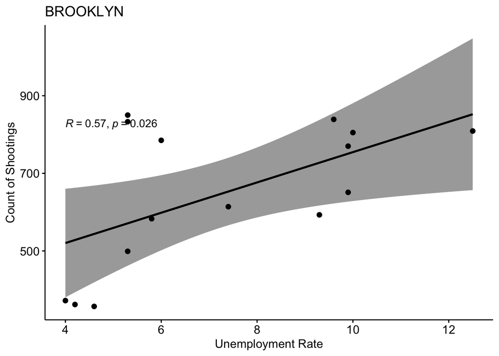

```r
# BROOKLYN
brooklyn_unemployment <- nyc_unemployment_by_year[nyc_unemployment_by_year$Boro == 'Brooklyn',]
brooklyn_shootings <- nypd_by_loc_year[nypd_by_loc_year$BORO == 'BROOKLYN',]
brooklyn <- cbind(brooklyn_shootings, brooklyn_unemployment)
ggscatter(brooklyn, x = "Unemployment_Rate", y = "count",
          add = "reg.line", conf.int = TRUE,
          cor.coef = TRUE, cor.method = "pearson",
          xlab = "Unemployment Rate", ylab = "Count of Shootings") +
          ggtitle("BROOKLYN")
```

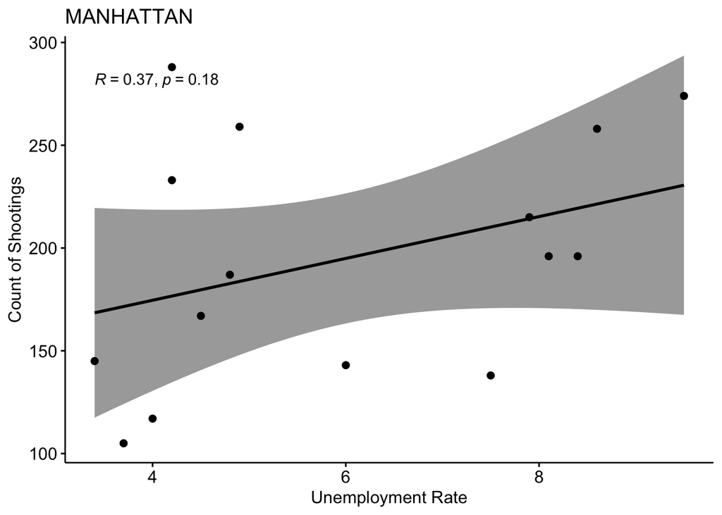

```r
# MANHATTAN
manhattan_unemployment <- nyc_unemployment_by_year[nyc_unemployment_by_year$Boro == 'Manhatten',]
manhattan_shootings <- nypd_by_loc_year[nypd_by_loc_year$BORO == 'MANHATTAN',]
manhattan <- cbind(manhattan_shootings, manhattan_unemployment)
ggscatter(manhattan, x = "Unemployment_Rate", y = "count",
          add = "reg.line", conf.int = TRUE,
          cor.coef = TRUE, cor.method = "pearson",
          xlab = "Unemployment Rate", ylab = "Count of Shootings") +
          ggtitle("MANHATTAN")
```

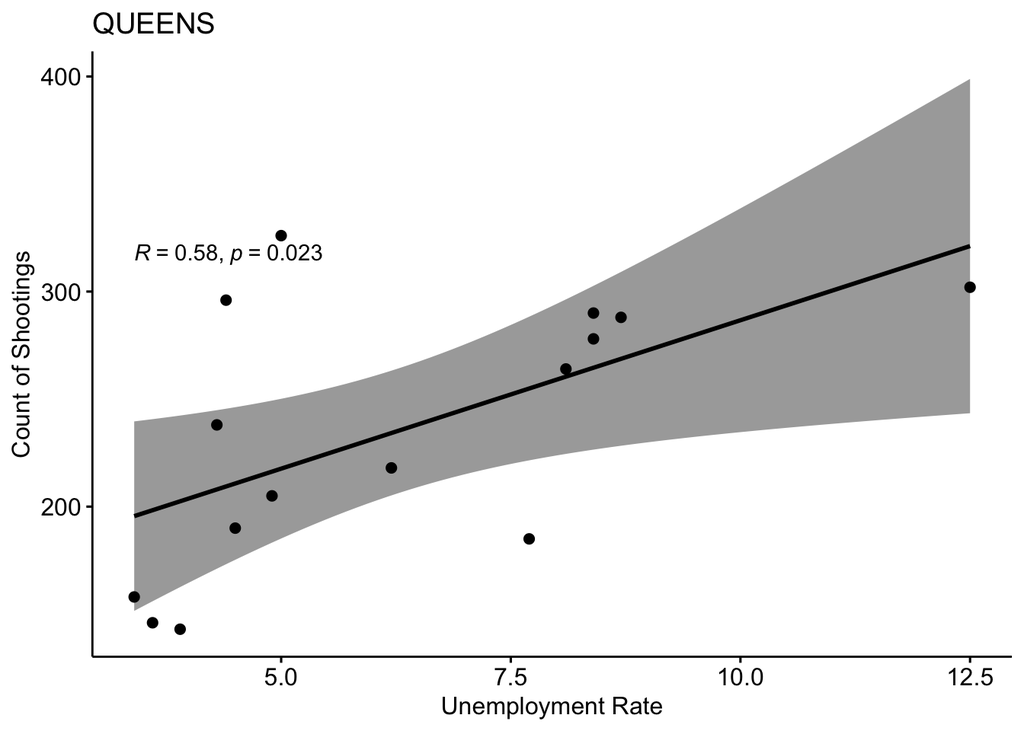

```r
# QUEENS
queens_unemployment <- nyc_unemployment_by_year[nyc_unemployment_by_year$Boro == 'Queens',]
queens_shootings <- nypd_by_loc_year[nypd_by_loc_year$BORO == 'QUEENS',]
queens <- cbind(queens_shootings, queens_unemployment)
ggscatter(queens, x = "Unemployment_Rate", y = "count",
          add = "reg.line", conf.int = TRUE,
          cor.coef = TRUE, cor.method = "pearson",
          xlab = "Unemployment Rate", ylab = "Count of Shootings") +
          ggtitle("QUEENS")
```

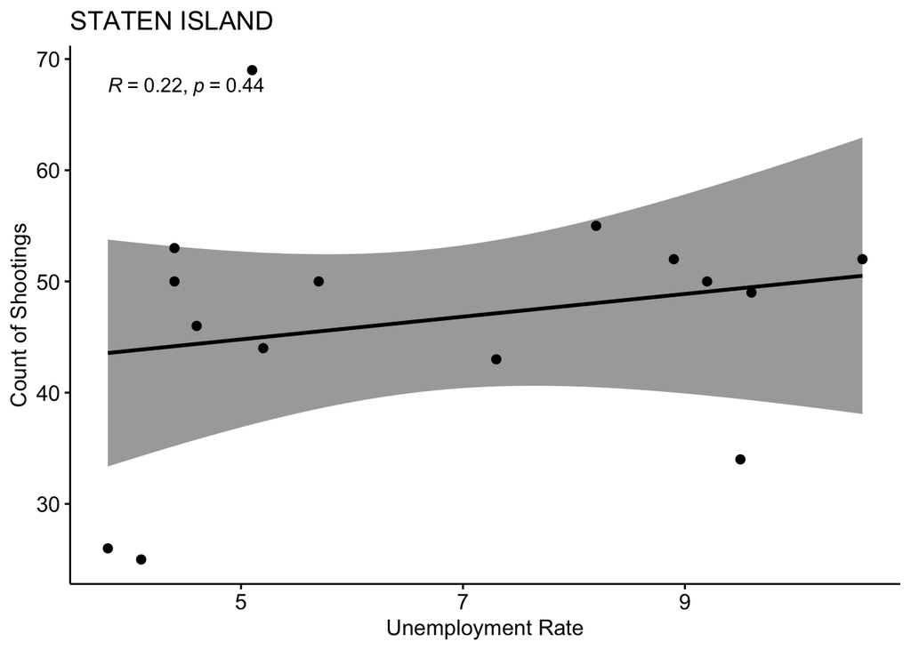

```r
# STATEN ISLAND
staten_island_unemployment <- nyc_unemployment_by_year[nyc_unemployment_by_year$Boro == 'Staten Island',]
staten_island_shootings <- nypd_by_loc_year[nypd_by_loc_year$BORO == 'STATEN ISLAND',]
staten_island <- cbind(staten_island_shootings, staten_island_unemployment)
ggscatter(staten_island, x = "Unemployment_Rate", y = "count",
          add = "reg.line", conf.int = TRUE,
          cor.coef = TRUE, cor.method = "pearson",
          xlab = "Unemployment Rate", ylab = "Count of Shootings") +
          ggtitle("STATEN ISLAND")
```

### Density Maps of Shootings

Taking a look at these density maps we can get a better idea of the areas where there was an increase in activity between 2019 and 2020. The smaller areas on the 2020 map show the same density as 2019 but in a smaller area meaning more shootings within that area. There are also 2 main clusters. A large one over Brooklyn, unsurprisingly as we have seen, and another large one over the border between Manhattan and Bronx. Staten Island is mostly clear which is also to be expected.

```r
df_2019 <- filter(nypd_shooting, year == 2019)
df_2019 <- data.table(df_2019)
## Create kernel density output
kde <- bkde2D(df_2019[ , list(Longitude, Latitude)],
              bandwidth=c(.0045, .0068), gridsize = c(2000,2000))
# Create Raster from Kernel Density output
KernelDensityRaster <- raster(list(x=kde$x1 ,y=kde$x2 ,z = kde$fhat))

#create pal function for coloring the raster
palRaster <- colorBin("Spectral", bins = 7, domain = KernelDensityRaster@data@values, na.color = "transparent")

#set low density cells as NA so we can make them transparent with the colorNumeric function
KernelDensityRaster@data@values[which(KernelDensityRaster@data@values < 1)] <- NA

## Leaflet map with raster
leaflet() %>% addTiles() %>%
  addRasterImage(KernelDensityRaster,
                 colors = palRaster,
                 opacity = .6) %>%
  addLegend(pal = palRaster,
            values = KernelDensityRaster@data@values,
            title = "Density of Shootings in 2019")
```

[interactive chart not shown]

```r
df_2020 <- filter(nypd_shooting, year == 2020)
df_2020 <- data.table(df_2020)
## Create kernel density output
kde <- bkde2D(df_2020[ , list(Longitude, Latitude)],
              bandwidth=c(.0022, .0068), gridsize = c(2000,2000))
# Create Raster from Kernel Density output
KernelDensityRaster <- raster(list(x=kde$x1 ,y=kde$x2 ,z = kde$fhat))

#create pal function for coloring the raster
palRaster <- colorBin("Spectral", bins = 7, domain = KernelDensityRaster@data@values, na.color = "transparent")

#set low density cells as NA so we can make them transparent with the colorNumeric function
KernelDensityRaster@data@values[which(KernelDensityRaster@data@values < 1)] <- NA

## Leaflet map with raster
leaflet() %>% addTiles() %>%
  addRasterImage(KernelDensityRaster,
                 colors = palRaster,
                 opacity = .6) %>%
  addLegend(pal = palRaster,
            values = KernelDensityRaster@data@values,
            title = "Density of Shootings in 2020")
```

[interactive chart not shown]

### Median Household Income

Now let’s take a look at the median household incomes for New York City to find those low income communities. This image was collected from Business Insider and was created with 2009-2013 data. However, the difference in these neighborhoods between then and now will be relatively the same for this analysis to find the lower income communities. Comparing our previous density map to this household income map, we can in fact see the most shootings are occurring in the lower income areas. These areas would have been hit the hardest by the pandemic with the large increase in unemployment rates previously shown. Staten Island for example has very few shootings and has mostly high income households.

[figure not shown]

# Conclusion

From my analysis, the pandemic has definitely had an impact. Increased unemployment rates and low household incomes cannot be declared the cause of the increased shootings, however, there is definitely a relationship there to explore further. Unemployment causes a lot of stress on low income communities which we have verified are where most of the shootings are taking place. More resources are needed for these low income communities to overcome this unfortunate economic hit.